# Decision Trees and Random Forests

## What is a Decision Tree?

A **decision tree** is a model composed of a collection of "questions" organized hierarchically in the shape of a tree.

The questions are usually called a **condition**, a **split**, or a **test**. We will use the term "condition" in this class. Each non-leaf node contains a condition, and each leaf node contains a prediction.

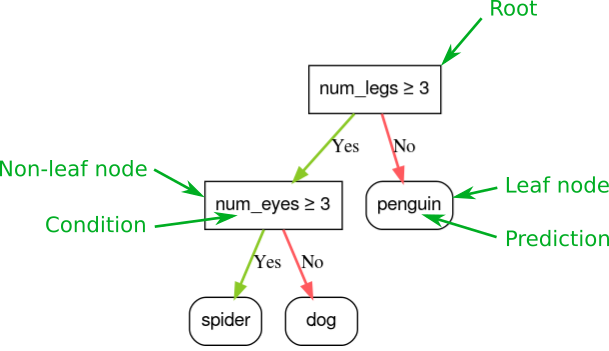

Inference of a decision tree model is computed by routing an example from the root (at the top) to one of the leaf nodes (at the bottom) according to the conditions. The value of the reached leaf is the decision tree's prediction. The set of visited nodes is called the **inference path**

Consider the example:

| num_legs | num_eyes |
| --- | --- |
| 4 | 2 |

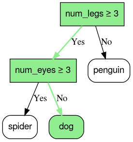

## Binary vs. non-binary conditions

Conditions with two possible outcomes (for example, true or false) are called **binary conditions**. Decision trees containing only binary conditions are called **binary decision trees**.

**Non-binary conditions** have more than two possible outcomes. Therefore, non-binary conditions have more discriminative power than binary conditions. Decisions containing one or more non-binary conditions are called **non-binary decision trees**.

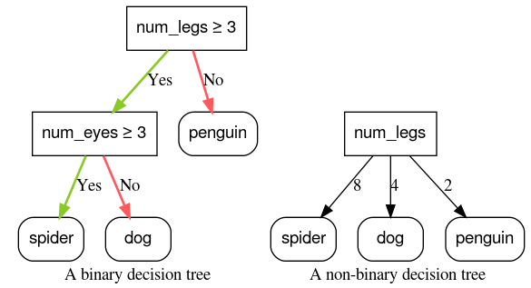

We generally use binary conditions, however, as non-binary conditions have a tendency to overfit

### Common Types of Binary Condition

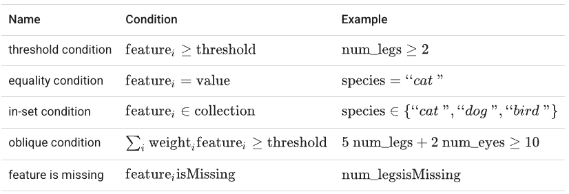

## Entropy

[figure not shown]

**Shannon entropy** is a measure of disorder. For a binary label:

- Shannon entropy is at a maximum when the labels in the examples are balanced (50% blue and 50% orange).
- Shannon entropy is at a minimum (value zero) when the labels in the examples are pure (100% blue or 100% orange).

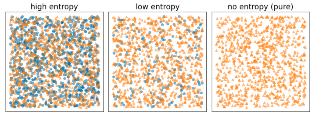

Formally, we want to find a condition that decreases the weighted sum of the entropy of the label distributions in $T$ and $F$. The corresponding score is the **information gain**, which is the difference between the dataset's entropy and $\{T,F\}$ entropy. This difference is called the information gain.

A better split will further minimize the entropy of the label:

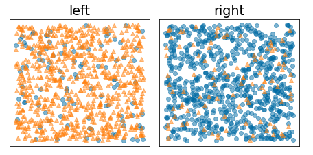

# Overfitting and Pruning

To limit overfitting a decision tree, we can apply one or both of the following **regularization criteria** while training the decision tree:

- Set a maximum depth: Prevent decision trees from growing past a maximum depth, such as 10.
- Set a minimum number of examples in leaf: A leaf with less than a certain number of examples will not be considered for splitting.

## Pruning Child Leaves

You can also regularize after training by selectively removing (pruning) certain branches. A common solution to select the branches to remove is to use a validation dataset:

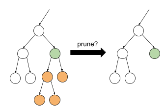